# WILD 591 – Spatial Population Modeling

Lesson 1: Introduction

Mahdieh Tourani

2026-10-07

# Where we’re going

## Roadmap for today

1. The role of space in ecology and conservation
2. Trajectory of spatial modeling frameworks
3. The shape of the rest of the semester

## Introduction

1. What is your name?
2. What do you study?
3. What is your favourite café in Missoula?

[figure not shown]

# 1.1 The Role of Space

## Tobler’s First Law of Geography

> “Everything is related to everything else, but near things are more related than distant things.”

This means that samples from nearby locations are more similar than samples far apart.

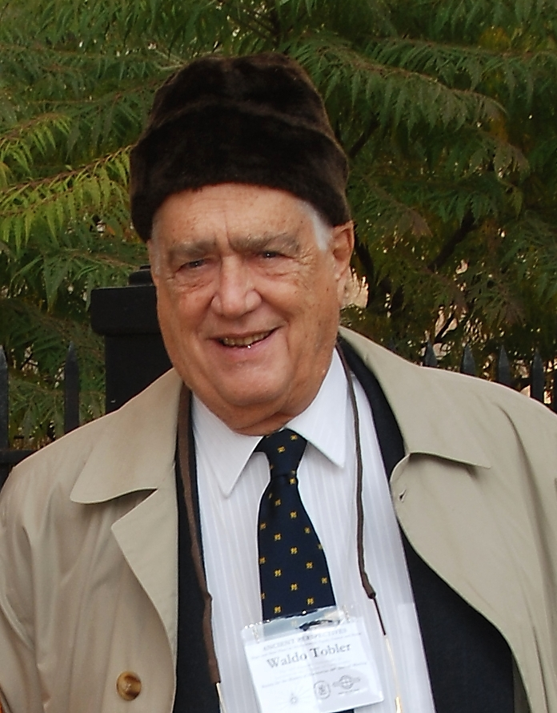

## Space: the final frontier

> Kareiva opened a 1994 *Ecology* editorial by calling space the final frontier for ecological theory.

Ecology had been about space (e.g., Darwin’s entangled bank and Hutchinson’s ecological theater).

- What changed in the 1990s was not the recognition that space matters. It was the arrival of **data that were spatially explicit** and **models that could use them**.

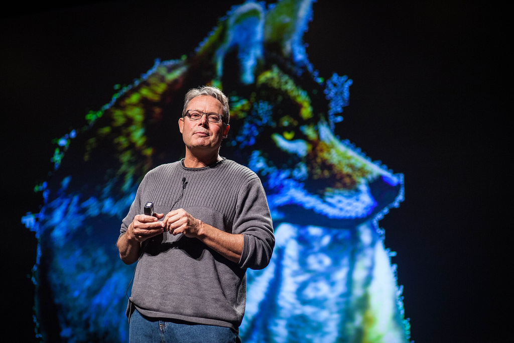

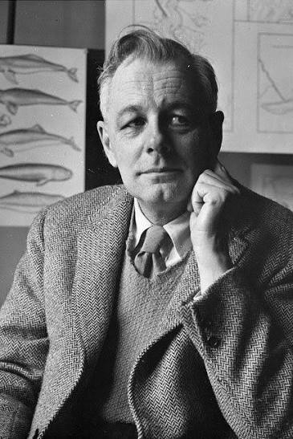

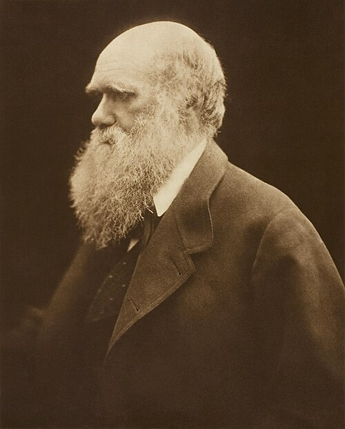

## Spatial ecology

> “The study and modeling of the role(s) of space on ecological processes, which in turn affect ecological patterns.”

Definition by Fletcher & Fortin, 2018

[figure not shown]

## Processes and patterns

We usually observe the pattern and want to infer the process.

- Space acts on **processes** (dispersal, competition, demography)
- Processes generate **patterns** (distributions, abundance surfaces)

  process → pattern → inference

# 1.2 Why Space Matters in Ecology?

## Space in Ecology: dependence

> All aspects of ecology play out in space.

If space is inherent to every ecological process, then any analysis that assumes observations are independent and identically located is making a claim about biology which is usually false.

## Space in Ecology: scale

> All aspects of ecology play out in space.

Spatial structure can alter outcomes of ecological studies.

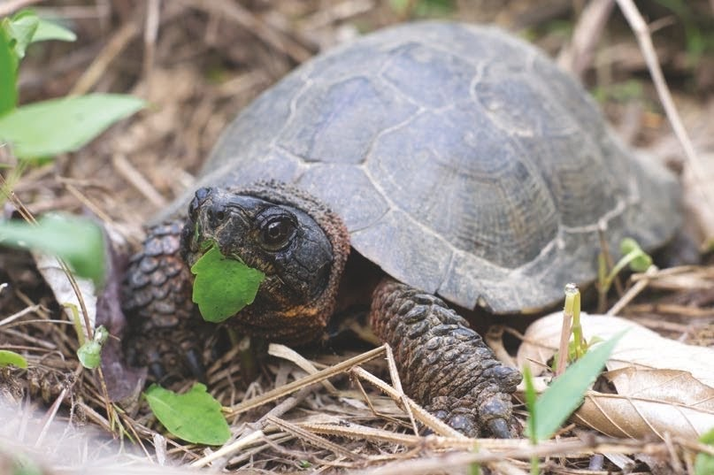

## Space-environment relationship

**SA-env**: Spatial structure of the environment

**SD**: Spatial dependence of species response to spatially structured environment

**SA-sp**: Spatial autocorrelation of the species

## Spatial pattern: SA-env

**SA-env**: Spatial structure of the environment

> SA-env is a property of the world, not of the sampling or the species.

## Spatial pattern: SA-sp

**SA-sp**: Spatial autocorrelation of the species

> Organisms cluster for endogenous reasons: limited dispersal, territoriality, conspecific attraction, contagious reproduction, local demographic history.

## Why does it matter?

All three produce similar maps, confusing them has direct costs:

- False positive error. Autocorrelated residuals violate independence; standard errors shrink, p-values shrink, and you discover relationships that are not there.
- Wrong mechanism. You attribute to habitat what dispersal produced, or vice versa.
- Bad extrapolation. A model fitted to a confounded signal predicts badly in a new landscape.

## Activity

**Format:** small groups of 2–3

**Materials:** one set of 11 cut cards per group, three labelled table zones (SA-env, SA-sp, SD)

Your group’s job: **sort those 11 cards (real ecological statements) into SA-env, SA-sp, SD.** (8min)

## Activity debrief

SA-env and SA-sp are things about the world; SD is the thing we want to estimate; and card 10 is a reminder that some spatial structure is about neither the world nor the organism but about study design.

# 2.1 The Need For Spatial Modeling Frameworks

## Theoretical Foundations

- Traditionally, ecological models ignored the role of space (e.g., classic Lotka-Volterra models).
- However, spatial structure can fundamentally alter outcomes:
  - Facilitates species coexistence by creating spatial refuges
  - Generates source-sink dynamics where sink habitats are sustained by immigration
  - Drives spatial population synchrony through regional climatic factors or dispersal

## Plant community: Watt 1947

> Pattern and process are linked, not separate objects of study.

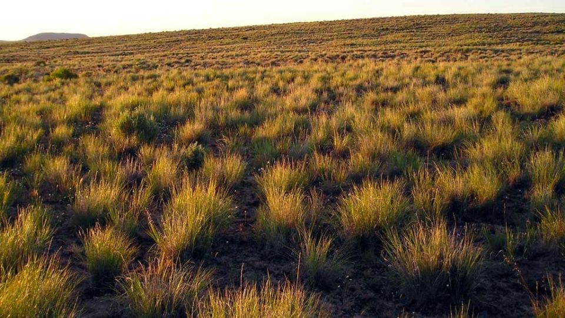

## Pattern and Process

> A static plant community is in fact a dynamic mosaic of patches rotating through life and death.
- Plants occur in bounded communities, i.e., patches, that together form a dynamic mosaic across the landscape.
- Patterns arise from processes such as competition and dispersal.

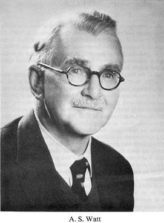

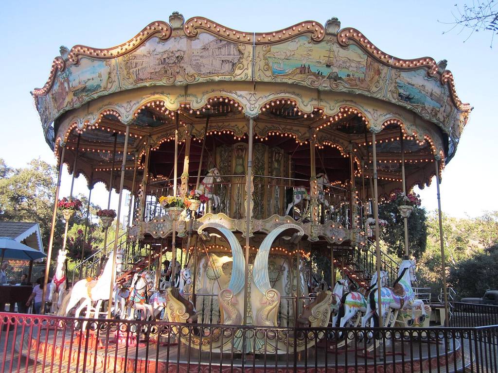

## Universe of oranges: Huffaker 1958

Lotka-Volterra models assume every predator can encounter every prey with equal probability.

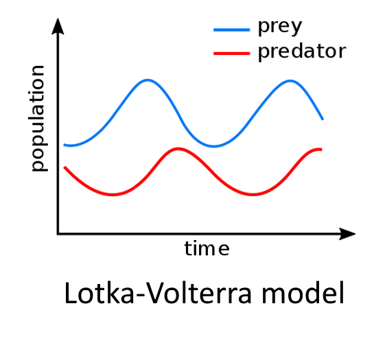

## Spatial refugia

> Space can stabilise an interaction that is unstable without it.

The physical layout of the landscape, i.e., spatial configuration, is what prevents total collapse or accelerates colonizations.

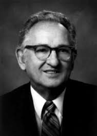

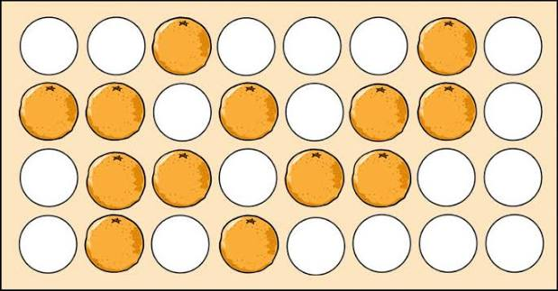

## Diffusion-reaction: Skellam 1951

> Animal populations move in a very similar way.

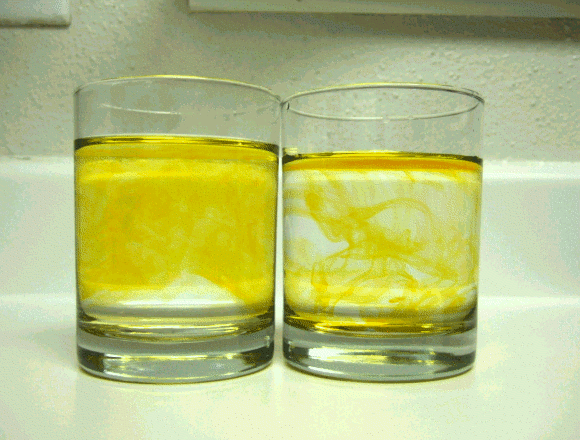

## Muskrat escape

> Speed of invasion is determined by how fast individuals wander, and how fast they breed.

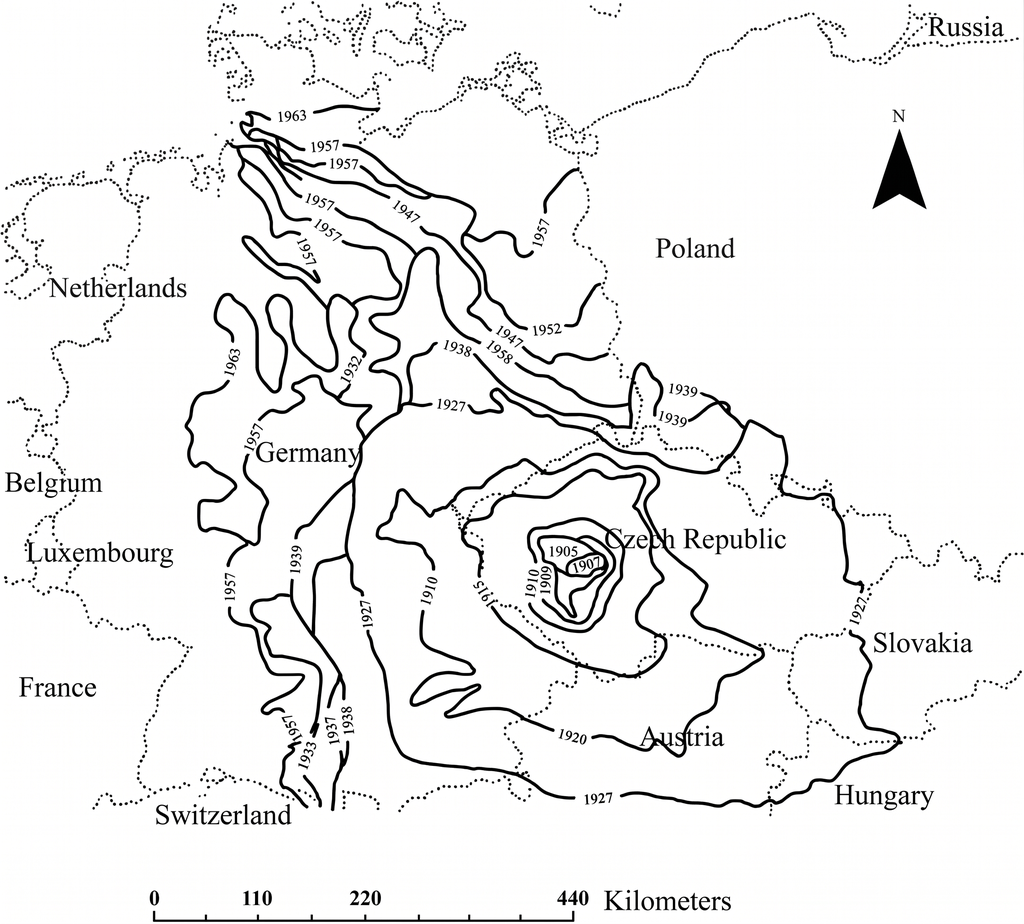

# 2.2 Towards Explicit Space

## Herbivorous insects: Kareiva 1992

> The diffusion coefficient is not a property of the organim: rather a property of the organism in a particular landscape.

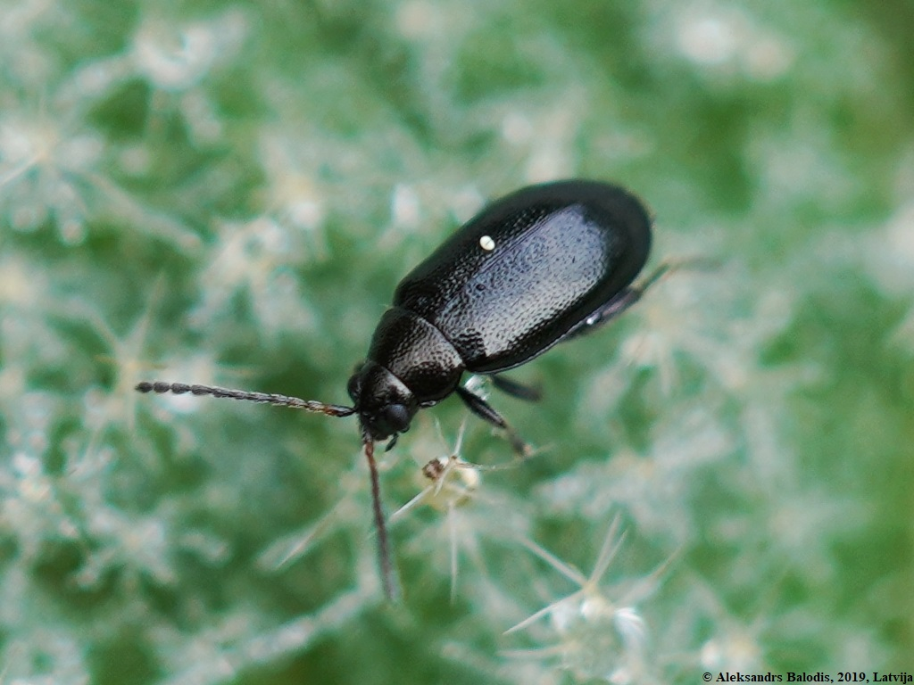

## Herbivorous insects: Kareiva 1993

Kareiva’s empirical test: diffusion models predicted spread adequately despite obviously non-random insect movement.

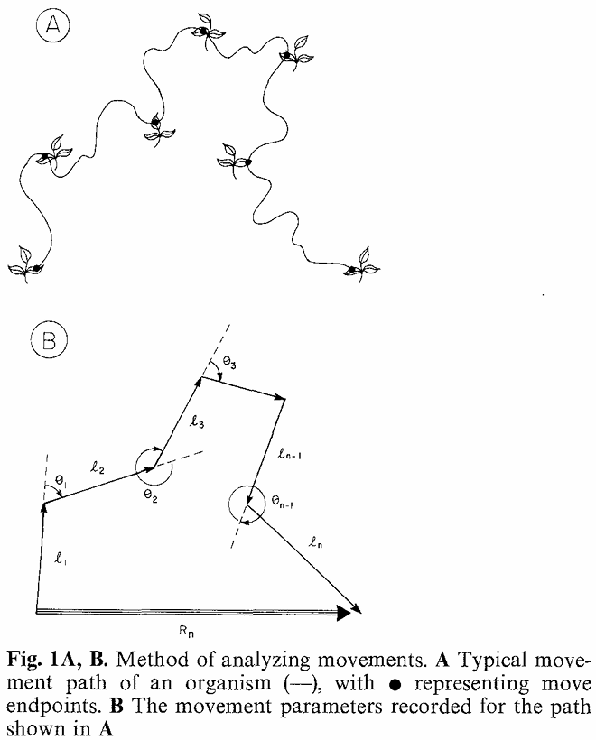

## Activity overview

**Format:** small groups of 2–3

**Materials:** one printed 10 × 10 grid per group, pens

Every group gets an identical landscape: a 10 × 10 grid, 100 cells. Every group gets exactly **25 cells of habitat** to shade in.

Your group’s job: **arrange those 25 cells to give your species the best possible chance of persisting for 100 years.** Shade them however you like.

**Before you start, draw one card from the card deck.** It tells you which species you are planning for. Do not show it to the other groups.

## Activity

**Design (<4 min).** Shade your 25 cells. Agree on your reasoning in one sentence.

**Gallery walk (<6 min).** Tape your grid to the wall. Walk the room. Do not talk yet, just look.

**Two questions, whole class (<10 min).**

1. Every landscape on this wall has **exactly the same amount of habitat**. Why do they look different?
2. Point to the grid you think is *worst*. Now find out which card that group drew.

## Activity debrief

Without being told any of the terminology, your group made decisions about:

- **Patch size and isolation** (the two axes of island biogeography theory)
- **Connectivity** (whether an individual can get from A to B)
- **Species-specific perception** of the same physical landscape
- **Configuration** (arrangement versus amount)

You also discovered the uncomfortable part: **the “right” map depends on the organism**, and two competent groups looking at identical data can reach opposite conclusions when the organism differs.

## Island biogeography: MacArthur & Wilson

> Patch size and spatial configuration govern persistence through colonization and extinction.

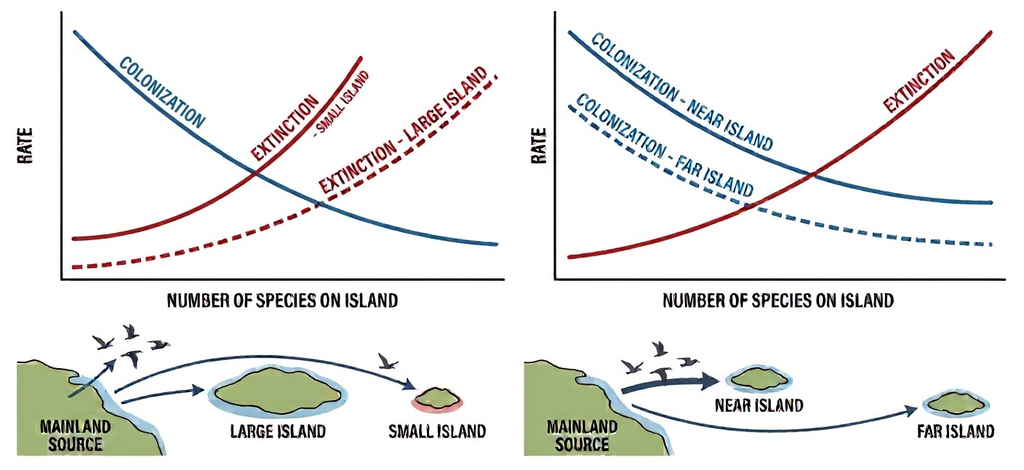

- **Area** → extinction rate (bigger islands, smaller extinction risk)
- **Isolation** → colonisation rate (nearer islands, higher colonisation)

## From islands to metapopulations

> Dispersal can protect a local population from extinction.

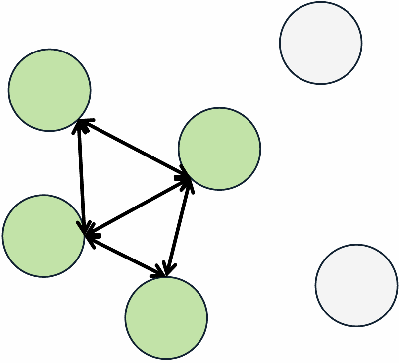

How to model metapopulation dynamics?

➢ each patch can be occupied (1) or unoccupied (0)

➢ at each time step, occupied patches go extinct with probability ε

➢ unoccupied patches can be colonized with probability γ

➢ objective is to estimate the fraction of patches occupied ѱ

## Metapopulation dynamic: Levins 1969

> More patches leads to lower metapopulation extinction risk

✓ Unoccupied sites are “rescued” by colonization from occupied sites

✓ Critical to maintain patches, even if they are currently unoccupied

✓ Connectivity of patches important for increasing colonization probability

## What made it possible

The emergence of spatial modelling frameworks was fostered by **technological advance** at least as much as by theory:

- Massive increases in high-resolution spatial data (e.g., GPS telemetry, LIDAR, remote sensing)
- Advanced statistical methods (e.g., Geostatistics, Species Distribution Models, Individual Based Models)
- Computing power
- Open-source software ecosystems, which allow reproducible script-based modelling

These allowed conceptual and modelling developments to represent space more realistically. The ability to explicitly include the effects of space was **pivotal in the explosion of novel ecological questions** over recent decades.

# 3.1 Shape of the Rest of the Semester

## How to incorporate space

| Spatial aspect | Effect on process and data |
| --- | --- |
| *x–y* coordinates | Locations of data relative to other locations |
| autocorrelation | Magnitude, scale, direction of data as a function of distance between observations |
| relationship | Locations of abiotic predictor affect biotic response |
| legacy | Past spatial pattern influences present process and pattern |
| contingency | Nearby locations influence process and pattern |
| perception | Intervening landscape features shape movement and dispersal ability |
| multiple scales | Several scales act additively on present spatial pattern |

## Syllabus

Access course syllabus on [Canvas](https://canvas.umt.edu/courses/34487/assignments/syllabus).